# Data Science for Bioinformatics - week 10

# Linear Models using the naked mole rat and the Mammals dataset

The aim of this session is to go through the different steps of linear models fitting and model checking

- Fitting a series of linear models to data
- Comparing models using F tests
- understand differences in type I, II etc sum of squares
- vizualizing the fit of a model to the data

# Load the data

```r
moleRat <- read.csv(url("http://www.zoology.ubc.ca/~schluter/WhitlockSchluter/wp-content/data/chapter18/chap18e4MoleRatLayabouts.csv"))
head(moleRat)
```

```
##    caste   lnMass lnEnergy
## 1 worker 3.850148 3.688879
## 2 worker 3.988984 3.688879
## 3 worker 4.110874 3.688879
## 4 worker 4.174387 3.663562
## 5 worker 4.248495 3.871201
## 6 worker 4.262680 3.850148
```

```r
moleRatSorted <- moleRat[ order(moleRat$lnMass), ]
summary(moleRat)
```

```
##     caste        lnMass         lnEnergy
##  lazy  :14   Min.   :3.850   Min.   :3.555
##  worker:21   1st Qu.:4.248   1st Qu.:3.902
##              Median :4.511   Median :4.190
##              Mean   :4.540   Mean   :4.193
##              3rd Qu.:4.844   3rd Qu.:4.489
##              Max.   :5.263   Max.   :5.043
```

## Model fitting

We fit severalmodels to the data, beginning with the model lacking an interaction term. We use the R function lm because both caste and mass are fixed effects. We first use a model with no interactions:

```r
moleRatNoInteractModel <- lm(lnEnergy ~ lnMass + caste, data = moleRatSorted) # fit model
moleRatSorted$predictedNoInteract <- predict(moleRatNoInteractModel) #save the predicted values in the data frame for vizualazing
```

Then, we fit a model with the interaction. Note that in the R function lm(), when we declare a general linear model of the form $Y = A*B$ it is a short hand for $Y = A + B + A*B$:

```r
moleRatFullModel <- lm(lnEnergy ~ lnMass * caste, data = moleRatSorted)
moleRatSorted$predictedInteract <- predict(moleRatFullModel)
```

> Question: Visualize the fit of both models (no interaction or with interactions) to the data (see for instance the book figure)

```r
library(tidyverse)
```

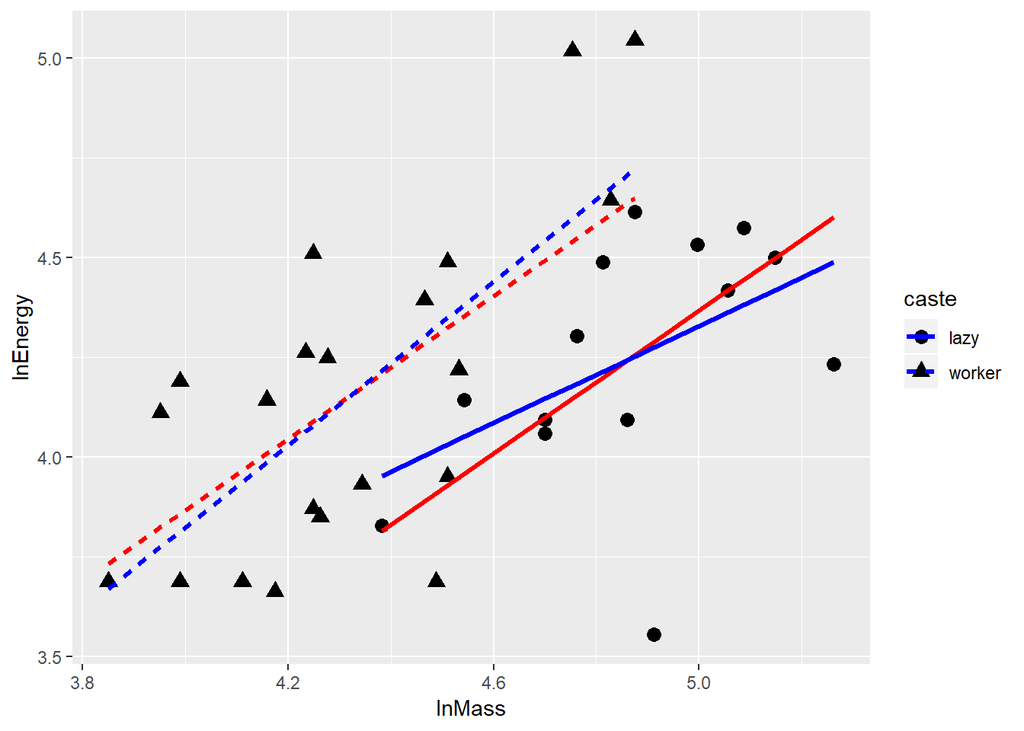

```r
ggplot(moleRatSorted) + geom_point(mapping = aes(lnMass, lnEnergy, shape = caste), size = 3) +
  geom_line(mapping = aes(lnMass, predictedNoInteract, linetype = caste), color = 'red', size = 1.2) +
  geom_line(mapping = aes(lnMass, predictedInteract, linetype = caste), color = 'blue', size = 1.2)
```

# Testing for the effect using the appropriate F-ratio test

This is were it gets slightly messy :-)- Reason is the design is not exaxtly balanced to it actually matterns how you construct F test (because the expected values of the F tests do change) Here is a good read about the joys of the different types (I, II etc) sum of squares: http://www.uni-kiel.de/psychologie/rexrepos/posts/anovaSStypes.html

```r
#install.packages("car")
library(car) ## You need to install this library to get the type II or type III sum of squares
moleRatNoInteractModelTypeIII <- lm(lnEnergy ~ lnMass + caste, data = moleRat)
moleRatWIthInteractModelTypeIII <- lm(lnEnergy ~ lnMass * caste, data = moleRat)

#Question: Why are we testing type 3 here? The model did not account for interaction. Shouldn't it be type 2?
Anova(moleRatWIthInteractModelTypeIII, type = "III") # note "A" in Anova is capitalized
```

```
## Anova Table (Type III tests)
##
## Response: lnEnergy
##               Sum Sq Df F value  Pr(>F)
## (Intercept)  0.05283  1  0.6010 0.44408
## lnMass       0.27558  1  3.1351 0.08646 .
## caste        0.05696  1  0.6481 0.42694
## lnMass:caste 0.08956  1  1.0188 0.32061
## Residuals    2.72494 31
## ---
## Signif. codes:  0 '***' 0.001 '**' 0.01 '*' 0.05 '.' 0.1 ' ' 1
```

```r
Anova(moleRatNoInteractModelTypeIII, type = "III") # note "A" in Anova is capitalized
```

```
## Anova Table (Type III tests)
##
## Response: lnEnergy
##              Sum Sq Df F value    Pr(>F)
## (Intercept) 0.00093  1  0.0106    0.9188
## lnMass      1.88152  1 21.3923 5.887e-05 ***
## caste       0.63747  1  7.2478    0.0112 *
## Residuals   2.81450 32
## ---
## Signif. codes:  0 '***' 0.001 '**' 0.01 '*' 0.05 '.' 0.1 ' ' 1
```

## Model checking

You can use the R diagnostic plots (just like in the case of ANOVA or regression) to visually check that the model assumptions are not strongly violated.

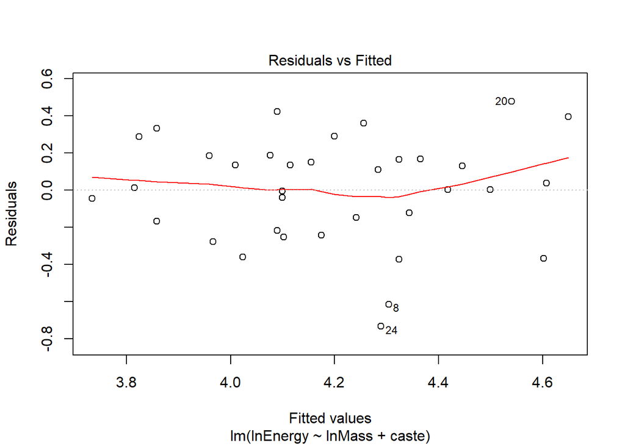

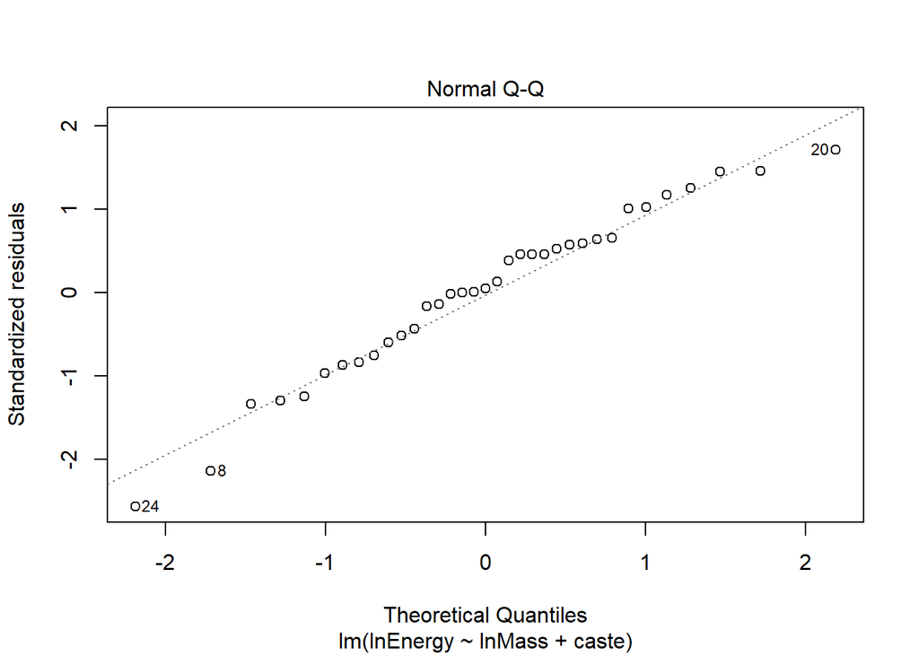

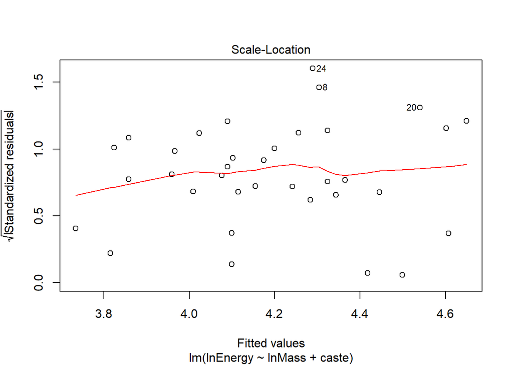

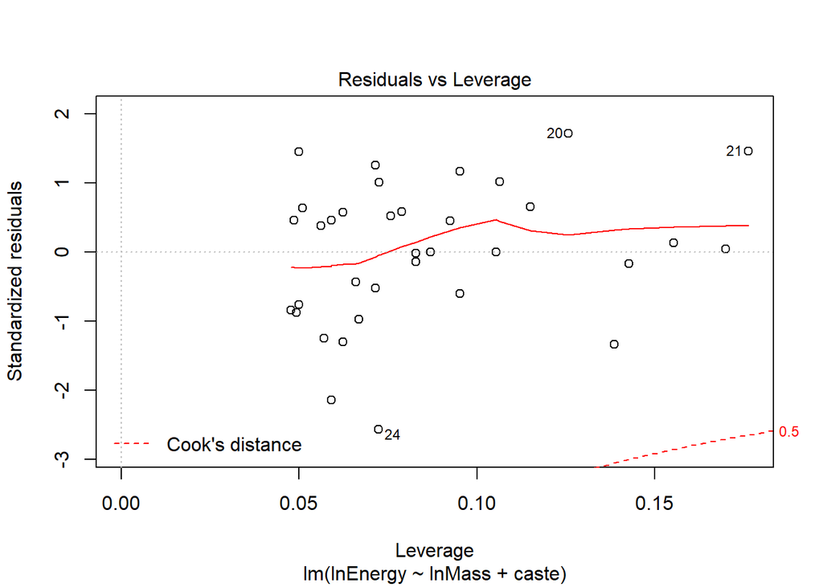

```r
#install.packages("ggfortify")

plot(moleRatNoInteractModelTypeIII) ## Old style
```

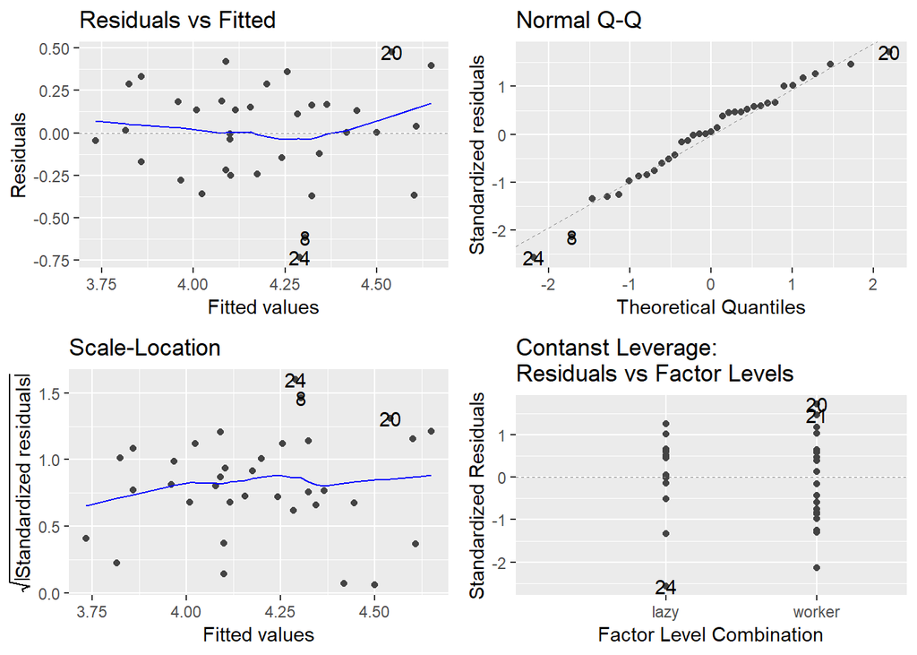

```r
library(ggfortify) ## New style
ggplot2::autoplot(moleRatNoInteractModelTypeIII)
```

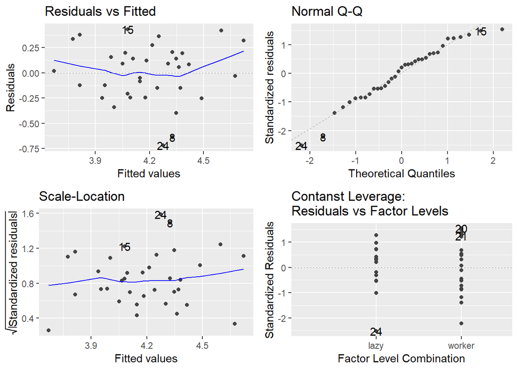

```r
ggplot2::autoplot(moleRatWIthInteractModelTypeIII)
```

# Reproducing the results obtained in the Mammals dn/ds and X versus autosome paper.

```r
library(tidyverse)
mammals <- read_csv(file = "../datasets/dataset.01.rsbl20150010supp1.csv")
```

> Q Spend a bit of time asking yourslef what terms of the models are (continuous) covariates or diecrete ANOVA-like factors

discrete: Species, chrMark continuous: log(RPKM), Tau, GC3

> Q Refit the model used by the authors in their publication:

$$log(dNdS) = Species+ chrMark + log(RPKM)+ Tau+ GC3$$

To do that, adapt the naked mole rat R code and lm() and the Anova() function of the car package, to refit the model used by the authors and check your findings against the findings reported in Table 2 of the publication. Note that the authors use type II sum of squares to fit their model.

```r
mam_mut = mammals %>% mutate(log_dNdS = log(dNdS), log_RPKM = log(RPKM))

mammalsNoInteractModel <- lm(log_dNdS ~ Species + chrMark + log_RPKM + Tau + GC3, data = mam_mut)
Anova(mammalsNoInteractModel, type = "II")
```

```
## Anova Table (Type II tests)
##
## Response: log_dNdS
##            Sum Sq    Df  F value    Pr(>F)
## Species    1359.2     5 445.0751 < 2.2e-16 ***
## chrMark       0.2     1   0.3458    0.5565
## log_RPKM     92.3     1 151.0407 < 2.2e-16 ***
## Tau          40.6     1  66.4226 3.885e-16 ***
## GC3         392.5     1 642.5846 < 2.2e-16 ***
## Residuals 10576.7 17317
## ---
## Signif. codes:  0 '***' 0.001 '**' 0.01 '*' 0.05 '.' 0.1 ' ' 1
```

```r
mammalsInteractModel <- lm(log_dNdS ~ Species + chrMark + log_RPKM + Tau + GC3
                           + Tau*log_RPKM + GC3 * log_RPKM + GC3*Tau
                           + Species*log_RPKM + Species*Tau + Species*GC3, data = mam_mut)
Anova(mammalsInteractModel, type = "III")
```

```
## Anova Table (Type III tests)
##
## Response: log_dNdS
##                   Sum Sq    Df  F value    Pr(>F)
## (Intercept)          6.8     1  11.3630 0.0007509 ***
## Species              3.7     5   1.2231 0.2951781
## chrMark              0.3     1   0.4643 0.4956117
## log_RPKM            68.8     1 114.4095 < 2.2e-16 ***
## Tau                  0.5     1   0.8095 0.3682757
## GC3                  6.9     1  11.5279 0.0006871 ***
## log_RPKM:Tau        41.6     1  69.2535 < 2.2e-16 ***
## log_RPKM:GC3        21.1     1  35.0586 3.260e-09 ***
## Tau:GC3              9.5     1  15.7871 7.117e-05 ***
## Species:log_RPKM    26.4     5   8.7677 2.559e-08 ***
## Species:Tau         14.9     5   4.9685 0.0001505 ***
## Species:GC3         36.9     5  12.2584 6.901e-12 ***
## Residuals        10402.5 17299
## ---
## Signif. codes:  0 '***' 0.001 '**' 0.01 '*' 0.05 '.' 0.1 ' ' 1
```

# Exploring the effect of not accounting for confounding variables.

> Q Fit a series of models that does not include the continuous covariates besides the species and chrMark factors.

Try four models, labelled S0, S1 S2 S3 (S for spurious ;-) ) :

$$S_0: log(dNdS) =Species+ chrMark$$

```r
model1 <- lm(log_dNdS ~ Species + chrMark, data = mam_mut)
Anova(model1, type = "II")
```

```
## Anova Table (Type II tests)
##
## Response: log_dNdS
##            Sum Sq    Df F value    Pr(>F)
## Species    1506.8     5 467.109 < 2.2e-16 ***
## chrMark      11.5     1  17.816 2.445e-05 ***
## Residuals 11173.9 17320
## ---
## Signif. codes:  0 '***' 0.001 '**' 0.01 '*' 0.05 '.' 0.1 ' ' 1
```

$$S_1: log(dNdS) =Species+ chrMark + Tau$$

```r
model2 <- lm(log_dNdS ~ Species + chrMark + Tau, data = mam_mut)
Anova(model2, type = "II")
```

```
## Anova Table (Type II tests)
##
## Response: log_dNdS
##            Sum Sq    Df F value    Pr(>F)
## Species    1538.7     5 479.109 < 2.2e-16 ***
## chrMark      10.8     1  16.859 4.044e-05 ***
## Tau          49.9     1  77.628 < 2.2e-16 ***
## Residuals 11124.0 17319
## ---
## Signif. codes:  0 '***' 0.001 '**' 0.01 '*' 0.05 '.' 0.1 ' ' 1
```

$$S_2: log(dNdS) =Species+ chrMark+ GC_3$$

```r
model3 <- lm(log_dNdS ~ Species + chrMark + GC3, data = mam_mut)
Anova(model3, type = "II")
```

```
## Anova Table (Type II tests)
##
## Response: log_dNdS
##            Sum Sq    Df  F value  Pr(>F)
## Species    1472.1     5 473.2704 < 2e-16 ***
## chrMark       2.4     1   3.8209 0.05063 .
## GC3         399.6     1 642.3418 < 2e-16 ***
## Residuals 10774.3 17319
## ---
## Signif. codes:  0 '***' 0.001 '**' 0.01 '*' 0.05 '.' 0.1 ' ' 1
```

$$S_3: log(dNdS) =Species+ chrMark + log(RPKM)$$

```r
model4 <- lm(log_dNdS ~ Species + chrMark + log_RPKM, data = mam_mut)
Anova(model4, type = "II")
```

```
## Anova Table (Type II tests)
##
## Response: log_dNdS
##            Sum Sq    Df  F value    Pr(>F)
## Species    1342.8     5 423.7672 < 2.2e-16 ***
## chrMark       4.2     1   6.6748  0.009787 **
## log_RPKM    197.7     1 311.8985 < 2.2e-16 ***
## Residuals 10976.2 17319
## ---
## Signif. codes:  0 '***' 0.001 '**' 0.01 '*' 0.05 '.' 0.1 ' ' 1
```

Examine the magnitude of this effect by finding out how big is the effect of the X versus Autosomes (the difference in means for that factors and what is the p-value attached to that effect) in models that do not include Tau log(RPKM) or GC3 as extra co-variates.